# *Analisis de avistamientos de UFOs* *en USA y eventos sociopoliticos* *mundiales usando Postgres*

### *¿Que paises han encabezado un evento importante en su momento?*

```r
    select MIN(avgtone), actor1countrycode from [gdelt-bq:full.events] group by actor1countrycode;
```

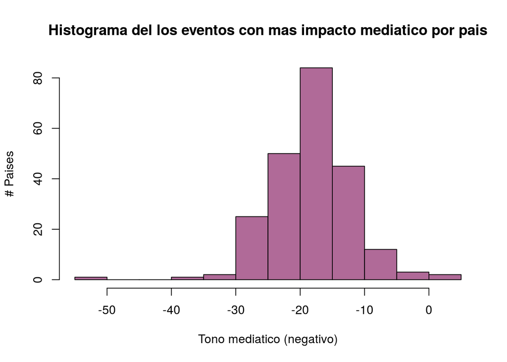

```r
avgtone_neg = read.csv("avg_neg.csv")
plot.avg_neg <- hist(avgtone_neg$f0_, breaks=10, col="#B06A98", xlab="Tono mediatico (negativo)", ylab="# Paises", main="Histograma del los eventos con mas impacto mediatico por pais")+
    theme(panel.background = element_blank())
```

```r
plot.avg_neg
```

### *Eventos en Mexico*

#### *Conflictos en Mexico*

Primero obtenemos los *conflictos en Mexico* y los guardamos en un csv:

```r
SELECT MonthYear, actor1geo_long, actor1geo_lat, actor1geo_fullname,
        count(*) c_mx
FROM [gdelt-bq:full.events]
WHERE eventcode = '19' AND actor1geo_countrycode = 'MX'
GROUP BY monthyear, actor1geo_long, actor1geo_lat, actor1geo_fullname
ORDER BY monthyear;
```

Usando las coordendas de los conflictos que arrojo la consulta, Se hizo un mapa de calor usando *rCharts* y *rMaps*. El codigo de los mapas es extenso y por ese motivo se adjunta como anexo.

El mapa de conflictos es el siguiente y se puede ver que las zona mas conflictiva es la zona inferior del pais.

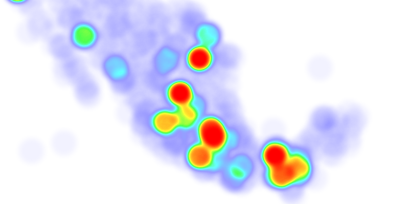

Si visitamos el mapa interactivo para darle zoom podemos observar que los focos de conflicto han sido la Ciudad de Mexico, Puebla, Leon, Oaxaca, y varias zonas de guerrillas de Chiapas y Tabasco:

Mapa de conflictos de Mexico interactivo

#### *Mexico vs el Mundo*

Para hacer una comparacion de Mexico vs el mundo, hacemos la siguiente consulta en *BigQuery*:

```r
SELECT Year, Actor1Name, Actor2Name, Count FROM (
    SELECT Actor1Name, Actor2Name, Year, COUNT(*) Count,
    RANK() OVER(PARTITION BY YEAR ORDER BY Count DESC) rank
    FROM
    (
        SELECT Actor1Name, Actor2Name,  Year
        FROM [gdelt-bq:full.events]
        WHERE Actor1Name < Actor2Name and Actor1CountryCode != '' and
        Actor2CountryCode != '' and Actor1CountryCode!=Actor2CountryCode
        and ActionGeo_CountryCode='MX'),
    (
        SELECT Actor2Name Actor1Name, Actor1Name Actor2Name, Year
        FROM [gdelt-bq:full.events]
        WHERE Actor1Name > Actor2Name  and Actor1CountryCode != ''
        and Actor2CountryCode != '' and Actor1CountryCode!= Actor2CountryCode
        and ActionGeo_CountryCode='MX'),
        WHERE Actor1Name IS NOT null
        AND Actor2Name IS NOT null
        GROUP EACH BY 1, 2, 3
        HAVING Count > 100
    )
    WHERE rank=1
    ORDER BY Year;
```

```r
mexvsmundo = read.csv("actoresmex.csv")
head(mexvsmundo)
```

```
##   Year Actor1Name    Actor2Name Count
## 1 1980     MEXICO UNITED STATES   118
## 2 1981     MEXICO UNITED STATES   179
## 3 1982     MEXICO UNITED STATES   225
## 4 1983     MEXICO UNITED STATES   326
## 5 1984     MEXICO UNITED STATES   291
## 6 1985     MEXICO UNITED STATES   433
```

Y los eventos anuales fueron los siguientes y vemos que desde 2005 el numero de eventos ha ido aumentando dramaticamente

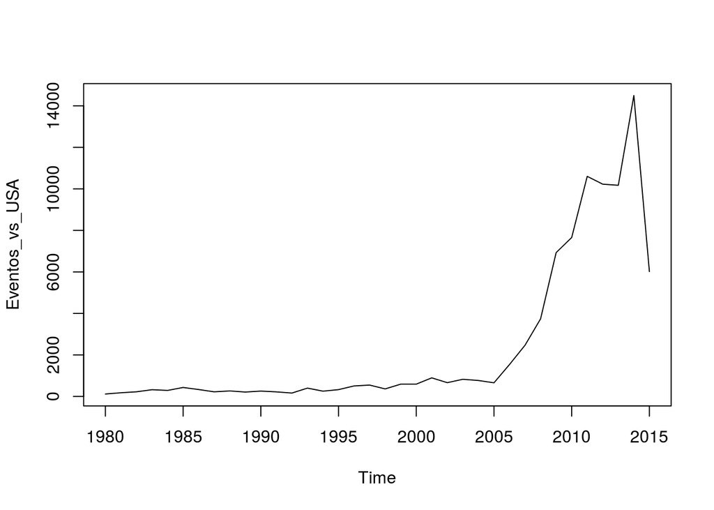

```r
Eventos_vs_USA<- ts(mexvsmundo$Count,start=c(1980), end=c(2015), frequency=1)
plot(Eventos_vs_USA)
```

## 4. Conclusiones

Como conclusiones podemos señalar que la variedad de consultas que se pueden hacer para la base de datos de GDELT es mucho mas rica que para la de avistamientos.

Este trabajo solo presenta las consultas mas basicas, hay un mar de posibilidades de Analitica sobre todo para la base de GDELT y nos parece muy relevante que las autoridades gubernamentales tengan a la mano este tipo de herramientas que, si son usadas adecuadamente, permitiran una mejor planeacion de politicas publicas.